# 2.1_Statistical_Distribution

## 作业 2.1 验证探测器计数的统计分布

- ROOT: TH1, TF1

#### 1. 在$^{137}$Cs放射源旁放置LaBr$_3$(Ce)探测器，利用定标器记录每秒间隔内探测器的计数。通过改变探测器与放射源的距离，得到两组不同计数率下的实验数据。其中一组探测器离放射源较近(high_counts.txt)，另一组探测器离放射源较远(low_counts.txt)。

**数据文件:**

- high counts
- low counts

**要求**：

1. 读入文件内数据，分别画出两组数据的计数率分布。
2. 利用Poisson 或 Gauss分布拟合计数率分布，求两种情况下的平均计数率，并验证poisson和gauss分布满足$\sigma = \sqrt{\mu}$。
   - Poisson分布函数： Double_t TMath::PoissonI(Double_t x, Double_t par)
   - Gaus分布函数：Double_t TMath::Gaus(Double_t x, Double_t mean = 0, Double_t sigma = 1)

### 预期效果：

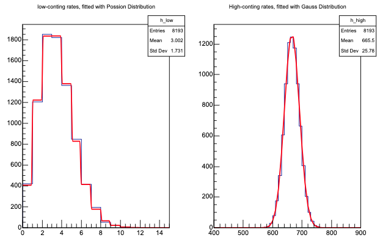

#### 2. 在$^{137}$ Cs 放射源旁放置 LaBr$_3$(Ce)探测器，记录每秒间隔内探测器的计数, 并记录相邻脉冲的时间间隔(时间单位$\mu$s) 。

**数据文件:**

- counts_per_second
- time_interval

**要求**：

1. 读入文件内数据，分别画出计数率分布，相邻事件时间间隔分布以及每5个事件的时间间隔分布。
2. 利用指数分布拟合相邻事件时间间隔分布，求出平均计数率，并与计数率测量给出的平均计数率进行比较。
- 指数函数：Double_t TMath::Exp(Double_t x)
- 利用指数分布拟合TH1:
  - h->Fit("expo"); // fit with function of f(x) = exp(p0+p1*x)

**参考链接**

- [相邻事件时间间隔分布](https://zhihuanli.github.io/Experimental-Method-in-Nuclear-Physics/chapt2/2.distribution_of_time_intervals.html)